# MR Base for two sample MR

Gibran Hemani

# Introduction

Two sample Mendelian randomisation (2SMR) is a method to estimate the causal effect of an exposure on an outcome using only summary statistics from genome wide association studies (GWAS). Though conceptually straightforward, there are a number of steps that are required to perform the analysis properly, and they can be cumbersome. The TwoSampleMR package aims to make this easy by combining three important components

- data management and harmonisation
- the statistical routines to estimate the causal effects
- a large repository of the actual GWAS summary statistics needed to perform the analyses.

The general principles (G. Davey Smith and Ebrahim 2003; George Davey Smith and Hemani 2014), and statistical methods (Pierce and Burgess 2013; Bowden, Davey Smith, and Burgess 2015) can be found elsewhere, here we will just outline how to use the R package.

## Installation

To install directly from the GitHub repository do the following:

```r
library(devtools)
install_github("MRCIEU/TwoSampleMR")
```

If you don’t have the `devtools` package install it from CRAN using `install.packages("devtools")`.

## Overview

The workflow for performing MR is as follows:

1. Select instruments for the exposure (perform LD clumping if necessary)
2. Extract the instruments from the MR Base GWAS database for the outcomes of interest
3. Harmonise the effect sizes for the instruments on the exposures and the outcomes to be each for the same reference allele
4. Perform MR analysis, sensitivity analyses, create plots, compile reports

A diagramatic overview is shown here:

[figure not shown]

A basic analysis, e.g. the causal effect of body mass index on coronary heart disease, looks like this:

```r
library(TwoSampleMR)

# List available GWASs
ao <- available_outcomes()

# Get instruments
exposure_dat <- read_exposure_data("path_to_bmi_instruments.txt")

# Get effects of instruments on outcome
outcome_dat <- extract_outcome_data(snps=exposure_dat$SNP, outcomes=7)

# Harmonise the exposure and outcome data
dat <- harmonise_data(exposure_dat, outcome_dat)

# Perform MR
res <- mr(dat)
```

Each step is documented in detail below.

## Authentication

In order to perform any commands that access data in the MR Base database, you must authenticate the request using OAuth2.0 authentication, using a Google account. For example, requesting a list of studies in the MR Base database:

```r
ao <- available_outcomes()
```

requires authentication.

If you are using a desktop computer this will open a web browser, navigating to a page that asks you to sign in to your Google account and authenticate access to MR Base.

If you are using a server which doesn’t have a graphic user interface then it will provide a link and a code to enter into a browser to authenticate access.

This function creates a new (hidden) file in your working directory called `.httr-oauth`. If you are using R in a working directory that does not have write permissions then this command will fail, please navigate to a directory that does have write permissions.

If you need to run this in a non-interactive script then you can generate the `.httr-oauth` file on an interactive computer, copy that file to the working directory that R will be running from, and then run a batch (non-interactive).

# Exposure data

A data frame of the instruments for an exposure is required. Each line has the information for one SNP for one exposure. The minimum information required for MR analysis is the following:

- `SNP` - rs ID
- `beta` - The effect size. If the trait is binary then log(OR) should be used
- `se` - The standard error of the effect size
- `effect_allele` - The allele of the SNP which has the effect marked in `beta`

Other information that is useful for MR can also be provided:

- `other_allele` - The non-effect allele
- `eaf` - The effect allele frequency
- `Phenotype` - The name of the phenotype for which the SNP has an effect

You can also provide the following extra information:

- `samplesize` - Sample size for estimating the effect size
- `ncase` - Number of cases
- `ncontrol` - Number of controls
- `pval` - The P-value for the SNP’s association with the exposure
- `units` - The units in which the effects are presented
- `gene` - The gene or other annotation for the the SNP

## Reading in from a file

The data can be read in from a text file using the `read_exposure_data` function. The file must have a header with column names corresponding to the columns described above.

### Example 1: The default column names are used

An example of a text file with the default column names is provided as part of the package, the first few rows look like this:

```
Phenotype SNP beta se effect_allele other_allele eaf pval units gene samplesize
BMI rs10767664 0.19 0.0306122448979592 A T 0.78 5e-26 kg/m2 BDNF 225238
BMI rs13078807 0.1 0.0204081632653061 G A 0.2 4e-11 kg/m2 CADM2 221431
BMI rs1514175 0.07 0.0204081632653061 A G 0.43 8e-14 kg/m2 TNNI3K 207641
BMI rs1558902 0.39 0.0204081632653061 A T 0.42 5e-120 kg/m2 FTO 222476
BMI rs10968576 0.11 0.0204081632653061 G A 0.31 3e-13 kg/m2 LRRN6C 247166
BMI rs2241423 0.13 0.0204081632653061 G A 0.78 1e-18 kg/m2 LBXCOR1 227886
```

The exact path to the file will be different on everyone’s computer, but it can be located like this:

```r
bmi_file <- system.file("data/bmi.txt", package="TwoSampleMR")
```

You can read the data in like this:

```r
bmi_exp_dat <- read_exposure_data(bmi_file)
head(bmi_exp_dat)
```

```
##          SNP beta.exposure se.exposure effect_allele.exposure
## 1 rs10767664          0.19  0.03061224                      A
## 2 rs13078807          0.10  0.02040816                      G
## 3  rs1514175          0.07  0.02040816                      A
## 4  rs1558902          0.39  0.02040816                      A
## 5 rs10968576          0.11  0.02040816                      G
## 6  rs2241423          0.13  0.02040816                      G
##   other_allele.exposure eaf.exposure pval.exposure units.exposure
## 1                     T         0.78         5e-26          kg/m2
## 2                     A         0.20         4e-11          kg/m2
## 3                     G         0.43         8e-14          kg/m2
## 4                     T         0.42        5e-120          kg/m2
## 5                     A         0.31         3e-13          kg/m2
## 6                     A         0.78         1e-18          kg/m2
##   gene.exposure samplesize.exposure exposure mr_keep.exposure
## 1          BDNF              225238      BMI             TRUE
## 2         CADM2              221431      BMI             TRUE
## 3        TNNI3K              207641      BMI             TRUE
## 4           FTO              222476      BMI             TRUE
## 5        LRRN6C              247166      BMI             TRUE
## 6       LBXCOR1              227886      BMI             TRUE
##   pval_origin.exposure units.exposure_dat id.exposure data_source.exposure
## 1             reported              kg/m2      uFvxtg             textfile
## 2             reported              kg/m2      uFvxtg             textfile
## 3             reported              kg/m2      uFvxtg             textfile
## 4             reported              kg/m2      uFvxtg             textfile
## 5             reported              kg/m2      uFvxtg             textfile
## 6             reported              kg/m2      uFvxtg             textfile
```

The output from this function is a new data frame with standardised column names:

- `SNP`
- `exposure`
- `beta.exposure`
- `se.exposure`
- `effect_allele.exposure`
- `other_allele.exposure`
- `eaf.exposure`
- `mr_keep.exposure`
- `pval.exposure`
- `pval_origin.exposure`
- `id.exposure`
- `data_source.exposure`
- `units.exposure`
- `gene.exposure`
- `samplesize.exposure`

The function attempts to match the columns to the ones it expects. It also checks that the data type is as expected.

If the required data for MR to be performed is not present (SNP name, effect size, standard error, effect allele) for a particular SNP, then the column `mr_keep.exposure` will be “FALSE”.

### Example 2: The text file has non-default column names

If the text file does not have default column names, this can still be read in as follows. Here are the first few rows of an example:

```
rsid,effect,SE,a1,a2,a1_freq,p-value,Units,Gene,n
rs10767664,0.19,0.030612245,A,T,0.78,5.00E-26,kg/m2,BDNF,225238
rs13078807,0.1,0.020408163,G,A,0.2,4.00E-11,kg/m2,CADM2,221431
rs1514175,0.07,0.020408163,A,G,0.43,8.00E-14,kg/m2,TNNI3K,207641
rs1558902,0.39,0.020408163,A,T,0.42,5.00E-120,kg/m2,FTO,222476
```

Note that this is a CSV file, with commas separating fields. The file is located here:

```r
bmi2_file <- system.file("data/bmi2.csv", package="TwoSampleMR")
```

To read in this data:

```r
bmi_exp_dat <- read_exposure_data(
    filename = bmi2_file,
    sep = ",",
    snp_col = "rsid",
    beta_col = "effect",
    se_col = "SE",
    effect_allele_col = "a1",
    other_allele_col = "a2",
    eaf_col = "a1_freq",
    pval_col = "p-value",
    units_col = "Units",
    gene_col = "Gene",
    samplesize_col = "n"
)
```

```
## No phenotype name specified, defaulting to 'exposure'.
```

```r
head(bmi_exp_dat)
```

```
##          SNP beta.exposure se.exposure effect_allele.exposure
## 1 rs10767664          0.19  0.03061224                      A
## 2 rs13078807          0.10  0.02040816                      G
## 3  rs1514175          0.07  0.02040816                      A
## 4  rs1558902          0.39  0.02040816                      A
## 5 rs10968576          0.11  0.02040816                      G
## 6  rs2241423          0.13  0.02040816                      G
##   other_allele.exposure eaf.exposure pval.exposure units.exposure
## 1                     T         0.78         5e-26          kg/m2
## 2                     A         0.20         4e-11          kg/m2
## 3                     G         0.43         8e-14          kg/m2
## 4                     T         0.42        5e-120          kg/m2
## 5                     A         0.31         3e-13          kg/m2
## 6                     A         0.78         1e-18          kg/m2
##   gene.exposure samplesize.exposure exposure mr_keep.exposure
## 1          BDNF              225238 exposure             TRUE
## 2         CADM2              221431 exposure             TRUE
## 3        TNNI3K              207641 exposure             TRUE
## 4           FTO              222476 exposure             TRUE
## 5        LRRN6C              247166 exposure             TRUE
## 6       LBXCOR1              227886 exposure             TRUE
##   pval_origin.exposure units.exposure_dat id.exposure data_source.exposure
## 1             reported              kg/m2      qZndKq             textfile
## 2             reported              kg/m2      qZndKq             textfile
## 3             reported              kg/m2      qZndKq             textfile
## 4             reported              kg/m2      qZndKq             textfile
## 5             reported              kg/m2      qZndKq             textfile
## 6             reported              kg/m2      qZndKq             textfile
```

If the `Phenotype` column is not provided (as is the case in this example) then it will assume that the phenotype’s name is simply “exposure”. This is entered in the `exposure` column. It can be renamed manually:

```r
bmi_exp_dat$exposure <- "BMI"
```

## Using an existing data frame

If the data already exists as a data frame in R then it can be converted into the correct format using the `format_data` function. For example, here is some randomly created data:

```r
random_df <- data.frame(
    SNP = c("rs1", "rs2"),
    beta = c(1, 2),
    se = c(1, 2),
    effect_allele = c("A", "T")
)
random_df
```

```
##   SNP beta se effect_allele
## 1 rs1    1  1             A
## 2 rs2    2  2             T
```

This can be formatted like so:

```r
random_exp_dat <- format_data(random_df, type="exposure")
```

```
## No phenotype name specified, defaulting to 'exposure'.
```

```
## Inferring p-values
```

```r
random_exp_dat
```

```
##   SNP beta.exposure se.exposure effect_allele.exposure exposure
## 1 rs1             1           1                      A exposure
## 2 rs2             2           2                      T exposure
##   mr_keep.exposure pval.exposure pval_origin.exposure id.exposure
## 1             TRUE     0.1586553             inferred      1OsoAX
## 2             TRUE     0.1586553             inferred      1OsoAX
##   other_allele.exposure eaf.exposure
## 1                    NA           NA
## 2                    NA           NA
```

## Obtaining instruments from existing catalogues

A number of sources of instruments have already been curated and are available for use in MR Base. They are provided as data objects in the `MRInstruments` package. To install:

```r
devtools::install_github("MRCIEU/MRInstruments")
```

This package contains a number of data.frames, each of which is a repository of SNP-trait associations. How to access the data frames is detailed below:

### GWAS catalog

The NHGRI-EBI GWAS catalog contains a catalog of significant associations obtained from GWASs. This version of the data is filtered and harmonised to contain associations that have the required data to perform MR, to ensure that the units used to report effect sizes from a particular study are all the same, and other data cleaning operations.

To use the GWAS catalog:

```r
library(MRInstruments)
data(gwas_catalog)
head(gwas_catalog)
```

```
##                                     Phenotype_simple
## 1 &beta;2-Glycoprotein I (&beta;2-GPI) plasma levels
## 2 &beta;2-Glycoprotein I (&beta;2-GPI) plasma levels
## 3 &beta;2-Glycoprotein I (&beta;2-GPI) plasma levels
## 4 &beta;2-Glycoprotein I (&beta;2-GPI) plasma levels
## 5 &beta;2-Glycoprotein I (&beta;2-GPI) plasma levels
## 6 &beta;2-Glycoprotein I (&beta;2-GPI) plasma levels
##                                            Phenotype Phenotype_info
## 1 &beta;2-Glycoprotein I (&beta;2-GPI) plasma levels
## 2 &beta;2-Glycoprotein I (&beta;2-GPI) plasma levels
## 3 &beta;2-Glycoprotein I (&beta;2-GPI) plasma levels
## 4 &beta;2-Glycoprotein I (&beta;2-GPI) plasma levels
## 5 &beta;2-Glycoprotein I (&beta;2-GPI) plasma levels
## 6 &beta;2-Glycoprotein I (&beta;2-GPI) plasma levels
##   PubmedID         Author Year        SNP chr bp_ens_GRCh38   Region
```

[output cut: 20 more lines]

For example, to obtain instruments for body mass index using the Speliotes et al 2010 study:

```r
bmi_gwas <- subset(gwas_catalog, grepl("Speliotes", Author) & Phenotype == "Body mass index (kg/m2 increase)")
bmi_exp_dat <- format_data(bmi_gwas)
```

### Metabolites

Independent top hits from GWASs on 121 metabolites in whole blood are stored in the `metab_qtls` data object. Use `?metab_qtls` to get more information.

```r
data(metab_qtls)
head(metab_qtls)
```

```
##   phenotype chromosome  position       SNP effect_allele other_allele
## 1     AcAce          8   9181395 rs2169387             G            A
## 2     AcAce         11 116648917  rs964184             C            G
## 3       Ace          6  12042473 rs6933521             C            T
## 4       Ala          2  27730940 rs1260326             C            T
## 5       Ala          2  65220910 rs2160387             C            T
## 6       Ala         12  47201814 rs4554975             G            A
##        eaf      beta       se     pval n_studies     n
## 1 0.870251  0.085630 0.015451 3.61e-08        11 19257
## 2 0.857715 -0.096027 0.014624 6.71e-11        11 19261
## 3 0.120256 -0.091667 0.015885 8.10e-09        14 24742
## 4 0.638817 -0.104582 0.009940 7.40e-26        13 22569
## 5 0.403170 -0.071001 0.009603 1.49e-13        14 24793
## 6 0.644059 -0.069135 0.009598 6.12e-13        14 24792
```

For example, to obtain instruments for the Alanine:

```r
ala_exp_dat <- format_metab_qtls(subset(metab_qtls, phenotype=="Ala"))
```

### Proteins

Independent top hits from GWASs on 47 protein levels in whole blood are stored in the `proteomic_qtls` data object. Use `?proteomic_qtls` to get more information.

```r
data(proteomic_qtls)
head(proteomic_qtls)
```

```
##   analyte chr  position        SNP  gene location annotation effect_allele
## 1   CFHR1   1 196698945 rs12144939   CFH      cis   missense             T
## 2    IL6r   1 154425456 rs12126142  IL6R      cis   missense             A
## 3   ApoA4  11 116677723  rs1263167 APOA4      cis intergenic             G
## 4    SELE   9 136149399   rs507666   ABO    trans   intronic             A
## 5 FetuinA   3 186335941  rs2070633  AHSG      cis   missense             T
## 6     ACE  17  61566031     rs4343   ACE      cis synonymous             A
##   other_allele   eaf      pval   beta         se
## 1            G 0.357 8.99e-143 -1.108 0.04355258
## 2            G 0.392 1.81e-106  0.850 0.03878364
## 3            A 0.197  2.64e-54 -0.919 0.05922332
## 4            G 0.191  1.01e-52 -0.882 0.05771545
## 5            C 0.324  2.88e-44 -0.629 0.04506925
## 6            G 0.492  6.66e-44  0.493 0.03547679
```

For example, to obtain instruments for the ApoH protein:

```r
apoh_exp_dat <- format_proteomic_qtls(subset(proteomic_qtls, analyte=="ApoH"))
```

### Gene expression levels

Independent top hits from GWASs on 27094 gene identifiers and in 44 tissues are available from the GTEX study in `gtex_eqtl`. Use `?gtex_eqtl` to get more information.

```r
data(gtex_eqtl)
head(gtex_eqtl)
```

```
##                 tissue     gene_name  gene_start        SNP snp_position
## 1 Adipose Subcutaneous    AC104698.1  2:30481193 rs72854266   2:30024901
## 2 Adipose Subcutaneous         GPR17 2:128403439 rs62161993  2:128405642
## 3 Adipose Subcutaneous          HAX1 1:154244987 rs35482991  1:154239334
## 4 Adipose Subcutaneous RP11-693J15.4 12:92815307  rs2129136  12:93048015
## 5 Adipose Subcutaneous      IRAK1BP1  6:79577189  rs9443645   6:79822924
## 6 Adipose Subcutaneous     RBPMS-AS1  8:30239635 rs10658617   8:30240091
##   effect_allele other_allele       beta         se         pval     n
## 1             C            G -0.2644880 0.05548197 3.137862e-06  2024
## 2             C            T  1.3835189 0.11229934 1.069910e-27 10000
## 3             T           TC  0.3002357 0.05335947 4.810291e-08 10000
## 4             T            C  0.3592790 0.07473484 2.610173e-06  1838
## 5             C            T  0.4259858 0.04844978 2.189240e-16 10000
## 6             A          AAT -0.3650559 0.03439368 4.764176e-22 10000
```

For example, to obtain instruments for the IRAK1BP1 gene expression levels in subcutaneous adipose tissue:

```r
irak1bp1_exp_dat <- format_gtex_eqtl(subset(gtex_eqtl, gene_name=="IRAK1BP1" & tissue == "Adipose Subcutaneous"))
```

```
## Inferring p-values
```

### DNA methylation levels

Independent top hits from GWASs on 0 DNA methylation levels in whole blood across 5 time points are available from the ARIES study in `aries_mqtl`. Use `?aries_mqtl` to get more information.

```r
data(aries_mqtl)
head(aries_mqtl)
```

```
##          SNP timepoint        cpg    beta        pval         se snp_chr
## 1 esv2656832         1 cg21826606  0.3459 1.60408e-26 0.03265336       1
## 2 esv2658098         1 cg22681495 -0.6263 1.55765e-66 0.03643240      15
## 3 esv2660043         1 cg24276624 -0.5772 3.16370e-26 0.05481823      11
## 4 esv2660043         1 cg11157765 -0.5423 1.33928e-22 0.05583777      11
## 5 esv2660673         1 cg05832925 -0.5919 2.88011e-50 0.03982467      11
## 6 esv2660769         1 cg05859533 -0.6224 1.49085e-58 0.03868158      16
##    snp_pos effect_allele other_allele    eaf   sex   age    units
## 1 25591901             I            R 0.3974 mixed Birth SD units
## 2 86057007             D            R 0.2076 mixed Birth SD units
## 3 69982552             D            R 0.1450 mixed Birth SD units
## 4 69982552             D            R 0.1450 mixed Birth SD units
## 5 74024905             D            R 0.1671 mixed Birth SD units
## 6 57725395             D            R 0.2136 mixed Birth SD units
##   island_location cpg_chr  cpg_pos    gene gene_location cis_trans
## 1         N_Shore       1 25593055                             cis
## 2                      15 86058755  AKAP13          Body       cis
## 3                      11 69982941    ANO1          Body       cis
## 4                      11 69982996    ANO1          Body       cis
## 5         S_Shelf      11 74026371                             cis
## 6                      16 57727230 CCDC135       TSS1500       cis
```

For example, to obtain instruments for cg25212131 CpG DNA methylation levels in at birth:

```r
cg25212131_exp_dat <- format_aries_mqtl(subset(aries_mqtl, cpg=="cg25212131" & age == "Birth"))
```

### MR Base GWAS database

The MR Base GWAS database contains the entire summary statistics for hundreds of GWASs. You can use this database to define the instruments for a particular exposure. You can also use this database to obtain the effects for constructing polygenic risk scores using different p-value thresholds.

For example, to obtain details about the available GWASs do the following:

```r
ao <- available_outcomes()
head(ao)
```

```
##           cat consortium ethnic
## 1 risk factor   ADIPOGen  mixed
## 2 risk factor      GIANT  mixed
## 3     disease    AMDGene  mixed
## 4     disease    AMDGene  mixed
## 5     disease    AMDGene  mixed
## 6     disease        C4D  mixed
##                                                             filename
## 1               adipogen.discovery.eur_.meta_.public.release.txt.tab
## 2              All_ancestries_SNP_gwas_mc_merge_nogc.tbl.uniq.gz.tab
## 3         AMDGene2013_Advanced_v_Controls.txt.gz.tab.all_pos.all_neg
## 4 AMDGene2013_GeographicAtropy_v_Controls.txt.gz.tab.all_pos.all_neg
## 5      AMDGene2013_Neovascular_v_Controls.txt.gz.tab.all_pos.all_neg
## 6                      C4D_CAD_DISCOVERY_METAANALYSIS_UPDATE.TXT.tab
##        gender id ncase ncontrol
```

[output cut: 41 more lines]

For information about authentication see the Authentication section.

The `available_outcomes` function returns a table of all the available studies in the database. Each study has a unique ID. e.g.

```r
head(subset(ao, select=c(trait, id)))
```

```
##                                                    trait id
## 1                                            adiponectin  1
## 2                                        body mass index  2
## 3            Age related macular degeneration (advanced)  3
## 4  Age related macular degeneration (geographic atrophy)  4
## 5 Age related macular degeneration (neovascular disease)  5
## 6                                 CoroNAry heart disease  6
```

To extract instruments for a particular trait using a particular study, for example to obtain SNPs for body mass index using the Locke et al 2015 GIANT study, you specify the study ID as follows:

```r
bmi2014_exp_dat <- extract_instruments(outcomes=2)
```

```
## Extracting data from 1 GWAS(s)
```

```
## and performing LD clumping
```

```
##  [>] 1 of 1
```

This returns a set of LD clumped SNPs that are GWAS significant for BMI. You can specify various parameters for this function:

- `p1` = P-value threshold for keeping a SNP
- `clump` = Whether or not to return independent SNPs only (default=TRUE)
- `r2` = The maximum LD R-square allowed between returned SNPs
- `kb` = The distance in which to search for LD R-square values

By changing changing the `p1` parameter it is possible to obtain SNP effects for constructing polygenic risk scores.

## Clumping

For standard two sample MR it is important to ensure that the instruments for the exposure are independent. Once instruments have been identified for an exposure variable, MR Base can be used to perform clumping.

The European samples from the 1000 genomes project are used to estimate LD between SNPs. You can provide a list of SNP IDs, the SNPs will be extracted from 1000 genomes data, LD calculated between them, and amongst those SNPs that have LD R-square above the specified threshold only the SNP with the lowest P-value will be retained. To do this, use the following command:

```r
bmi_exp_dat <- clump_data(bmi_exp_dat)
```

```
## Clumping eJaCNv, 32 SNPs
```

The `clump_data` command takes any data frame that has been formatted to be an exposure data type of data frame. Note that for the instruments in the R/MRInstruments package the SNPs are already LD clumped.

# Outcome data

Once instruments for the exposure trait have been specified, those SNPs need to be extracted from the outcome trait.

## Available studies in MR Base

MR Base contains complete GWAS summary statistics from a large number of studies. To obtain details about the available GWASs do the following:

```r
ao <- available_outcomes()
head(ao)
```

```
##           cat consortium ethnic
## 1 risk factor   ADIPOGen  mixed
## 2 risk factor      GIANT  mixed
## 3     disease    AMDGene  mixed
## 4     disease    AMDGene  mixed
## 5     disease    AMDGene  mixed
## 6     disease        C4D  mixed
##                                                             filename
## 1               adipogen.discovery.eur_.meta_.public.release.txt.tab
## 2              All_ancestries_SNP_gwas_mc_merge_nogc.tbl.uniq.gz.tab
## 3         AMDGene2013_Advanced_v_Controls.txt.gz.tab.all_pos.all_neg
## 4 AMDGene2013_GeographicAtropy_v_Controls.txt.gz.tab.all_pos.all_neg
## 5      AMDGene2013_Neovascular_v_Controls.txt.gz.tab.all_pos.all_neg
## 6                      C4D_CAD_DISCOVERY_METAANALYSIS_UPDATE.TXT.tab
##        gender id ncase ncontrol
```

[output cut: 41 more lines]

For information about authentication see the Authentication section.

The `available_outcomes` function returns a table of all the available studies in the database. Each study has a unique ID. e.g.

```r
head(subset(ao, select=c(trait, id)))
```

```
##                                                    trait id
## 1                                            adiponectin  1
## 2                                        body mass index  2
## 3            Age related macular degeneration (advanced)  3
## 4  Age related macular degeneration (geographic atrophy)  4
## 5 Age related macular degeneration (neovascular disease)  5
## 6                                 CoroNAry heart disease  6
```

## Extracting particular SNPs from particular studies

If we want to perform MR of BMI against coronary heart disease, we need to identify the SNPs that influence the BMI, and then extract those SNPs from a GWAS on coronary heart disease.

We have already extracted the 32 SNP effects for BMI:

```r
head(bmi_exp_dat)
```

```
##          SNP gene.exposure effect_allele.exposure other_allele.exposure
## 1 rs10150332         NRXN3                      C                     T
## 2 rs10767664          BDNF                      A                     T
## 3 rs10938397        GNPDA2                      G                     A
## 4 rs10968576        LRRN6C                      G                     A
## 5 rs11847697         PRKD1                      T                     C
## 6 rs12444979        GPRC5B                      C                     T
##   beta.exposure se.exposure pval.exposure units.exposure eaf.exposure
## 1          0.13  0.03061224         3e-11 kg/m2 increase         0.21
## 2          0.19  0.03061224         5e-26 kg/m2 increase         0.78
## 3          0.18  0.02040816         4e-31 kg/m2 increase         0.43
## 4          0.11  0.02040816         3e-13 kg/m2 increase         0.31
## 5          0.17  0.05102041         6e-11 kg/m2 increase         0.04
## 6          0.17  0.03061224         3e-21 kg/m2 increase         0.87
##                           exposure mr_keep.exposure pval_origin.exposure
## 1 Body mass index (kg/m2 increase)             TRUE             reported
## 2 Body mass index (kg/m2 increase)             TRUE             reported
## 3 Body mass index (kg/m2 increase)             TRUE             reported
## 4 Body mass index (kg/m2 increase)             TRUE             reported
## 5 Body mass index (kg/m2 increase)             TRUE             reported
## 6 Body mass index (kg/m2 increase)             TRUE             reported
##   units.exposure_dat id.exposure
## 1     kg/m2 increase      eJaCNv
## 2     kg/m2 increase      eJaCNv
## 3     kg/m2 increase      eJaCNv
## 4     kg/m2 increase      eJaCNv
## 5     kg/m2 increase      eJaCNv
## 6     kg/m2 increase      eJaCNv
```

We now need to find a suitable GWAS for coronary heart disease. We can search the available studies:

```r
ao[grepl("heart disease", ao$trait), ]
```

```
##       cat        consortium    ethnic
## 6 disease               C4D     mixed
## 7 disease CARDIoGRAMplusC4D     mixed
## 8 disease        CARDIoGRAM Caucasian
## 9 disease CARDIoGRAMplusC4D     mixed
##                                               filename      gender id
## 6        C4D_CAD_DISCOVERY_METAANALYSIS_UPDATE.TXT.tab both gender  6
## 7                       cad.add.160614.website.txt.tab both gender  7
## 8                   CARDIoGRAM_GWAS_RESULTS.txt.gz.tab both gender  8
## 9 cardiogramplusc4d_180814_update_data.txt.tab.all_pos both gender  9
##   ncase ncontrol note
## 6 15420    15062 <NA>
## 7 60801   123504 <NA>
## 8 22233    64762 <NA>
## 9 63746   130681 <NA>
##                                                        path     pmid
## 6 /projects/MRC-IEU/publicdata/GWAS_summary_data/cardiogram 21378988
## 7 /projects/MRC-IEU/publicdata/GWAS_summary_data/cardiogram 26343387
## 8 /projects/MRC-IEU/publicdata/GWAS_summary_data/cardiogram 21378990
## 9 /projects/MRC-IEU/publicdata/GWAS_summary_data/cardiogram 23202125
##   priority public sample_size sd         subcat
## 6        3 public       30482 NA cardiovascular
## 7        1 public      184305 NA cardiovascular
## 8        2 public       86995 NA cardiovascular
## 9        1 public      194427 NA cardiovascular
##                               trait           trait_strict     unit year
## 6            CoroNAry heart disease CoroNAry heart disease log odds 2011
## 7 CoroNAry heart disease (additive) CoroNAry heart disease log odds 2015
## 8            CoroNAry heart disease CoroNAry heart disease log odds 2011
## 9            CoroNAry heart disease CoroNAry heart disease log odds 2013
```

The most recent CARDIOGRAM GWAS is ID number 7. We can extract the BMI SNPs from this GWAS as follows:

```r
chd_out_dat <- extract_outcome_data(
    snps = bmi_exp_dat$SNP,
    outcomes = 7
)
```

```
## Extracting data for 32 SNP(s) from 1 GWAS(s)
```

The `extract_outcome_data` is a flexible function. The `snps` argument only requires an array of rsIDs, and the `outcomes` variable can be a vector of outcomes. e.g. `chd_out_dat(c("rs234", "rs17097147"), c(2, 7))` will extract the two SNPs from each of the outcomes 2 and 7.

## LD proxies

By default if a particular requested SNP is not present in the outcome GWAS then a SNP (proxy) that is in LD with the requested SNP (target) will be searched for instead. LD proxies are defined using 1000 genomes European sample data. The effect of the proxy SNP on the outcome is returned, along with the proxy SNP, the effect allele of the proxy SNP, and the corresponding allele (in phase) for the target SNP.

The parameters for handling LD proxies are as follows:

- `proxies` = TRUE or FALSE (TRUE by default)
- `rsq` = numeric value of minimum rsq to find a proxy. Default is 0.8, minimum is 0.6
- `palindromes` = Allow palindromic SNPs? Default is 1 (yes)
- `maf_threshold` = If palindromes allowed then what is the maximum minor allele frequency of palindromes allowed? Default is 0.3.

## Using local GWAS summary data

If you have GWAS summary data that is not present in MR Base, this can still be to perform analysis, though the LD proxy functionality is not currently available.

Supposing there is a GWAS summary file called “gwas_summary.csv” with e.g. 2 million rows and it looks like this:

```
rsid,effect,SE,a1,a2,a1_freq,p-value,Units,Gene,n
rs10767664,0.19,0.030612245,A,T,0.78,5.00E-26,kg/m2,BDNF,225238
rs13078807,0.1,0.020408163,G,A,0.2,4.00E-11,kg/m2,CADM2,221431
rs1514175,0.07,0.020408163,A,G,0.43,8.00E-14,kg/m2,TNNI3K,207641
rs1558902,0.39,0.020408163,A,T,0.42,5.00E-120,kg/m2,FTO,222476
...
...
```

To extract the exposure SNPs from this data, we would use the following command:

```r
outcome_dat <- read_outcome_data(
    snps = bmi_exp_dat$SNP,
    filename = "gwas_summary.csv",
    sep = ",",
    snp_col = "rsid",
    beta_col = "effect",
    se_col = "SE",
    effect_allele_col = "a1",
    other_allele_col = "a2",
    eaf_col = "a1_freq",
    pval_col = "p-value",
    units_col = "Units",
    gene_col = "Gene",
    samplesize_col = "n"
)
```

This returns an outcome data frame with only the SNPs that were requested (if those SNPs were present in the “gwas_summary.csv” file).

## Outcome data format

The `extract_outcome_data` function returns a table of SNP effects for the requested SNPs on the requested outcomes. The format of the data is similar to the exposure data format, except the main columns are as follows:

- `SNP`
- `beta.outcome`
- `se.outcome`
- `samplesize.outcome`
- `ncase.outcome`
- `ncontrol.outcome`
- `pval.outcome`
- `eaf.outcome`
- `effect_allele.outcom`
- `other_allele.outcome`
- `units.outcome`
- `outcome`
- `consortium.outcome`
- `year.outcome`
- `pmid.outcome`
- `id.outcome`
- `originalname.outcome`
- `proxy.outcome`
- `target_snp.outcome`
- `proxy_snp.outcome`
- `target_a1.outcome`
- `target_a2.outcome`
- `proxy_a1.outcome`
- `proxy_a2.outcome`
- `mr_keep.outcome`
- `data_source.outcome`

# Harmonise data

The exposure data and outcome data are now obtained, but it is important to harmonise the effects. This means that the effect of a SNP on the exposure and the effect of that SNP on the outcome must each correspond to the same allele.

To harmonise the exposure and outcome data, do the following:

```r
dat <- harmonise_data(
    exposure_dat = bmi_exp_dat,
    outcome_dat = chd_out_dat
)
```

```
## Harmonising Body mass index (kg/m2 increase) (eJaCNv) and CoroNAry heart disease (additive) || CARDIoGRAMplusC4D || 2015 (7)
```

```
## Removing the following SNPs due to harmonising issues:
## rs4836133
```

This creates a new data frame that has the exposure data and outcome data combined.

If there were 3 exposure traits and 3 outcome traits then there will be 9 sets of harmonisations being performed - harmonising the SNP effects of exposure trait 1 against outcome trait 1; exposure trait 1 against outcome trait 2; and so on.

## Dealing with strand issues

Recent GWASs typically present the effects of a SNP in reference to the allele on the forward strand. But as reference panels are updated the forward strand sometimes changes, and GWASs from a few years ago aren’t guaranteed to be using forward strand conventions.

Some examples are shown below:

### Correct, unambigious

```
exposure effect = 0.5
effect allele = A
other allele = G

outcome effect = 0.05
effect allele = A
other allele = G
```

Here the effect allele on the exposure and the outcome is the same

### Incorrect reference, unambigious

```
exposure effect = 0.5
effect allele = A
other allele = G

outcome effect = -0.05
effect allele = C
other allele = T
```

Here the outcome GWAS is presenting the effect for the alternate allele on the reverse strand. We need to flip the outcome effect to 0.05 to correspond to the same allele as the exposure GWAS on the forward strand.

### Ambiguous

```
exposure effect = 0.5
effect allele = A
other allele = G

outcome effect = -0.05
effect allele = A
other allele = C
```

Here the alleles do not correspond for the same SNP, so this SNP will be discarded from the analysis.

### Palindromic SNP, inferrable

```
exposure effect = 0.5
effect allele = A
other allele = T
effect allele frequency = 0.11

outcome effect = -0.05
effect allele = A
other allele = T
effect allele frequency = 0.91
```

Here the alleles correspond, but it is a palindromic SNP, such that the alleles on the forward strand are the same as on the reverse strand (A/T on forward is T/A on the reverse). However, the allele frequency of the effect allele gives us information - if the outcome effect allele (A) were on the forward strand we would expect it to have a low allele frequency, but given it has a high frequency (0.91) we infer that the outcome GWAS is presenting the effect on the reverse strand for the alternative allele. We would flip the effect to 0.05 for the outcome GWAS.

### Palindromic SNP, not inferrable

```
exposure effect = 0.5
effect allele = A
other allele = T
effect allele frequency = 0.50

outcome effect = -0.05
effect allele = A
other allele = T
effect allele frequency = 0.50
```

This is similar to the above, except the allele frequency no longer gives us information about the strand. We would discard this SNP. This is done for any palindromic SNPs that have minor allele frequency above 0.42.

### Options

There are three options to harmonising the data.

1. Assume all alleles are presented on the forward strand
2. Try to infer the forward strand alleles using allele frequency information
3. Correct the strand for non-palindromic SNPs, but drop all palindromic SNPs

By default, the `harmonise_data` function uses option 2, but this can be modified using the `action` argument, e.g. `harmonise_data(exposure_dat, outcome_dat, action=3)`.

# Perform MR

Once the exposure and outcome data are harmonised, we have effects and standard errors for each instrument SNP available for the exposure and outcome traits. We can use this information to perform Mendelian randomisation. To do this, simply run:

```r
res <- mr(dat)
```

```
## Analysing 'eJaCNv' on '7'
```

```r
res
```

```
##   id.exposure id.outcome
## 1      eJaCNv          7
## 2      eJaCNv          7
## 3      eJaCNv          7
## 4      eJaCNv          7
## 5      eJaCNv          7
## 6      eJaCNv          7
## 7      eJaCNv          7
##                                                          outcome
## 1 CoroNAry heart disease (additive) || CARDIoGRAMplusC4D || 2015
## 2 CoroNAry heart disease (additive) || CARDIoGRAMplusC4D || 2015
## 3 CoroNAry heart disease (additive) || CARDIoGRAMplusC4D || 2015
## 4 CoroNAry heart disease (additive) || CARDIoGRAMplusC4D || 2015
## 5 CoroNAry heart disease (additive) || CARDIoGRAMplusC4D || 2015
## 6 CoroNAry heart disease (additive) || CARDIoGRAMplusC4D || 2015
```

[output cut: 25 more lines]

This returns a data frame of estimates of the causal effect of the exposure on the outcome for a range of different MR methods.

If there were multiple exposures against multiple outcomes in `dat`, the `mr()` function will perform each MR method for each combination of exposure-outcome traits.

## Available methods

The list of available MR methods can be obtained:

```r
mr_method_list()
```

```
##                              obj
## 1                  mr_wald_ratio
## 2           mr_meta_fixed_simple
## 3                  mr_meta_fixed
## 4                 mr_meta_random
## 5               mr_two_sample_ml
## 6            mr_egger_regression
## 7  mr_egger_regression_bootstrap
## 8             mr_weighted_median
## 9   mr_penalised_weighted_median
## 10                        mr_ivw
##                                           name PubmedID Description
## 1                                   Wald ratio
## 2      Fixed effects meta analysis (simple SE)
## 3   Fixed effects meta analysis (delta method)
```

[output cut: 18 more lines]

To perform them, they can be specified in the `mr()` function, e.g. to only perform MR Egger regression and Inverse variance weighted methods,

```r
mr(dat, method_list=c("mr_egger_regression", "mr_ivw"))
```

```
## Analysing 'eJaCNv' on '7'
```

```
##   id.exposure id.outcome
## 1      eJaCNv          7
## 2      eJaCNv          7
##                                                          outcome
## 1 CoroNAry heart disease (additive) || CARDIoGRAMplusC4D || 2015
## 2 CoroNAry heart disease (additive) || CARDIoGRAMplusC4D || 2015
##                           exposure                    method nsnp
## 1 Body mass index (kg/m2 increase)                  MR Egger   31
## 2 Body mass index (kg/m2 increase) Inverse variance weighted   31
##           b         se         pval
## 1 0.1128175 0.03150704 1.232201e-03
## 2 0.1125964 0.01533203 2.075131e-13
```

By default, all the methods that are labelled `TRUE` in the `use_by_default` column are used by the `mr()` function.

## Sensitivity analyses

### Heterogeneity statistics

Some of the MR methods can also perform tests for heterogeneity. To obtain those statistics:

```r
mr_heterogeneity(dat)
```

```
##   id.exposure id.outcome
## 1      eJaCNv          7
## 2      eJaCNv          7
## 3      eJaCNv          7
## 4      eJaCNv          7
## 5      eJaCNv          7
##                                                          outcome
## 1 CoroNAry heart disease (additive) || CARDIoGRAMplusC4D || 2015
## 2 CoroNAry heart disease (additive) || CARDIoGRAMplusC4D || 2015
## 3 CoroNAry heart disease (additive) || CARDIoGRAMplusC4D || 2015
## 4 CoroNAry heart disease (additive) || CARDIoGRAMplusC4D || 2015
## 5 CoroNAry heart disease (additive) || CARDIoGRAMplusC4D || 2015
##                           exposure
## 1 Body mass index (kg/m2 increase)
## 2 Body mass index (kg/m2 increase)
## 3 Body mass index (kg/m2 increase)
## 4 Body mass index (kg/m2 increase)
## 5 Body mass index (kg/m2 increase)
##                                        method        Q Q_df     Q_pval
## 1  Fixed effects meta analysis (delta method) 36.16867   30 0.20260692
## 2 Random effects meta analysis (delta method) 36.16867   30 0.20260692
## 3                          Maximum likelihood 41.94788   30 0.07231219
## 4                                    MR Egger 44.40882   29 0.03355273
## 5                   Inverse variance weighted 42.92862   30 0.05944987
```

As with the `mr()` function, the `mr_heterogeneity()` function can take an argument to only perform heterogeneity tests using specified methods, e.g.

```r
mr_heterogeneity(dat, method_list=c("mr_egger_regression", "mr_ivw"))
```

```
##   id.exposure id.outcome
## 1      eJaCNv          7
## 2      eJaCNv          7
##                                                          outcome
## 1 CoroNAry heart disease (additive) || CARDIoGRAMplusC4D || 2015
## 2 CoroNAry heart disease (additive) || CARDIoGRAMplusC4D || 2015
##                           exposure                    method        Q Q_df
## 1 Body mass index (kg/m2 increase)                  MR Egger 44.40882   29
## 2 Body mass index (kg/m2 increase) Inverse variance weighted 42.92862   30
##       Q_pval
## 1 0.03355273
## 2 0.05944987
```

### Horizontal pleiotropy

The intercept term in MR Egger regression can be a useful indication of whether directional horizontal pleiotropy is driving the results of an MR analysis. This can be obtained as follows:

```r
mr_pleiotropy_test(dat)
```

```
##   id.exposure id.outcome
## 1      eJaCNv          7
##                                                          outcome
## 1 CoroNAry heart disease (additive) || CARDIoGRAMplusC4D || 2015
##                           exposure egger_intercept         se      pval
## 1 Body mass index (kg/m2 increase)     -3.9422e-05 0.00488063 0.9936107
```

### Single SNP analysis

To obtain the MR estimates using each of the SNPs singly we can do the following:

```r
res_single <- mr_singlesnp(dat)
```

This returns a data.frame of results that is similar to the output from `mr()` except it performs the analysis multiple times for each exposure-outcome combination - each time using a different single SNP to perform the analysis.

The method used to perform the single SNP MR is the Wald ratio by default, though this can be changed, e.g. to use the fixed effects meta analysis method instead:

```r
res_single <- mr_singlesnp(dat, single_method="mr_meta_fixed")
```

The `mr_singlesnp()` function calculates the full MR using all available SNPs as well, and by default it uses the IVW and MR Egger methods. This can be specified as so:

```r
res_single <- mr_singlesnp(dat, all_method="mr_two_sample_ml")
```

will perform only the maximum likelihood method for the combined test.

### Leave-one-out analysis

It is possible to perform a leave-one-out analysis, where the MR is performed again but leaving out each SNP in turn, to identify if a single SNP is driving the association.

```r
res_loo <- mr_leaveoneout(dat)
```

By default the method used is the inverse variance weighted method, but this can be changed by using the `method` argument.

## Plots

There are a few ways to visualise the results, listed below

### Scatter plot

We can depict the relationship of the SNP effects on the exposure against the SNP effects on the outcome using a scatter plot.

```r
res <- mr(dat)
```

```
## Analysing 'eJaCNv' on '7'
```

```r
p1 <- mr_scatter_plot(res, dat)
```

A scatter plot is created for each exposure-outcome test, and stored in `p1` as a list of plots. For example, to plot the first scatter plot:

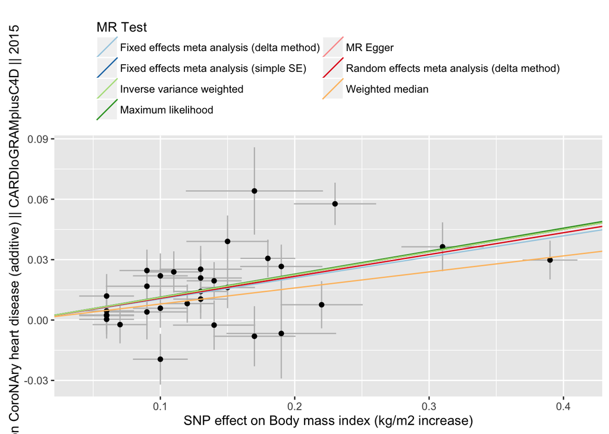

```r
p1[[1]]
```

And to see how many plots there are:

```r
length(p1)
```

```
## [1] 1
```

Lines are drawn for each method used in `mr(dat)`, the slope of the line corresponding to the estimated causal effect. To limit which lines are drawn, simply specify the desired methods, e.g. to only draw MR Egger and IVW:

```r
res <- mr(dat, method_list=c("mr_egger_regression", "mr_ivw"))
```

```
## Analysing 'eJaCNv' on '7'
```

```r
p1 <- mr_scatter_plot(res, dat)
```

It is possible to save this plot using the `ggsave()` function, e.g. to save as a pdf

```r
ggsave(p1[[1]], file="filename.pdf", width=7, height=7)
```

or save as a png

```r
ggsave(p1[[1]], file="filename.png", width=7, height=7)
```

See `?ggsave` for more info.

### Forest plot

Use the `mr_forest_plot()` function to compare the MR estimates using the different MR methods against the single SNP tests.

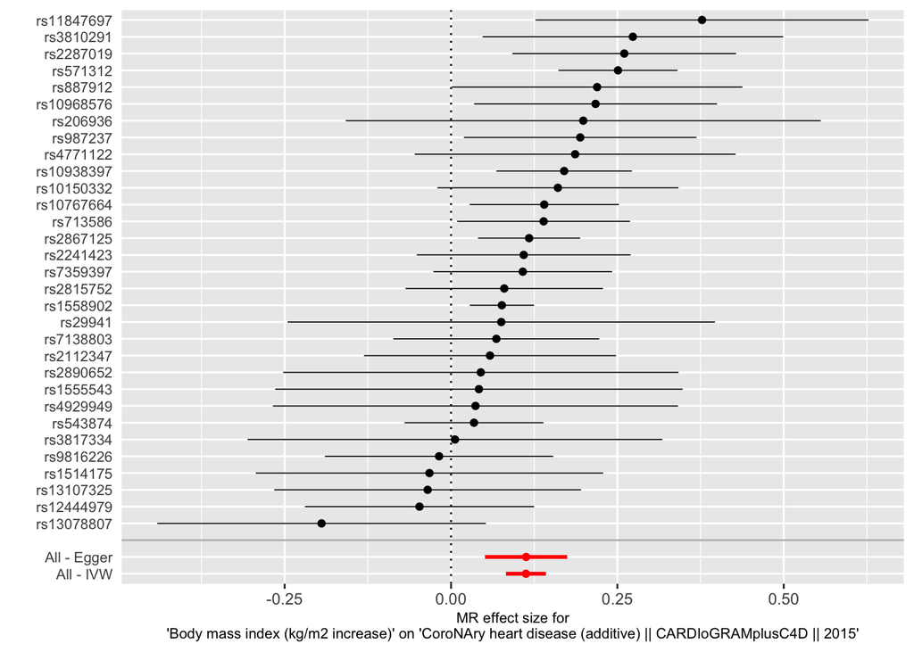

```r
res_single <- mr_singlesnp(dat)
p2 <- mr_forest_plot(res_single)
p2[[1]]
```

Here, the plot shows the causal effect as estimated using each of the SNPs on their own, and comparing against the causal effect as estimated using the methods that use all the SNPs.

To get plots that use different methods, specify them in the `mr_singlesnp()` function:

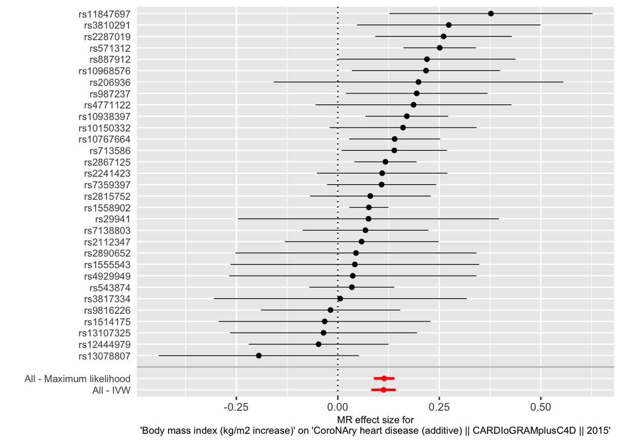

```r
res_single <- mr_singlesnp(dat, all_method=c("mr_ivw", "mr_two_sample_ml"))
p2 <- mr_forest_plot(res_single)
p2[[1]]
```

### Leave-one-out plot

Use the `mr_leaveoneout_plot` function to visualise the leave-one-out analysis:

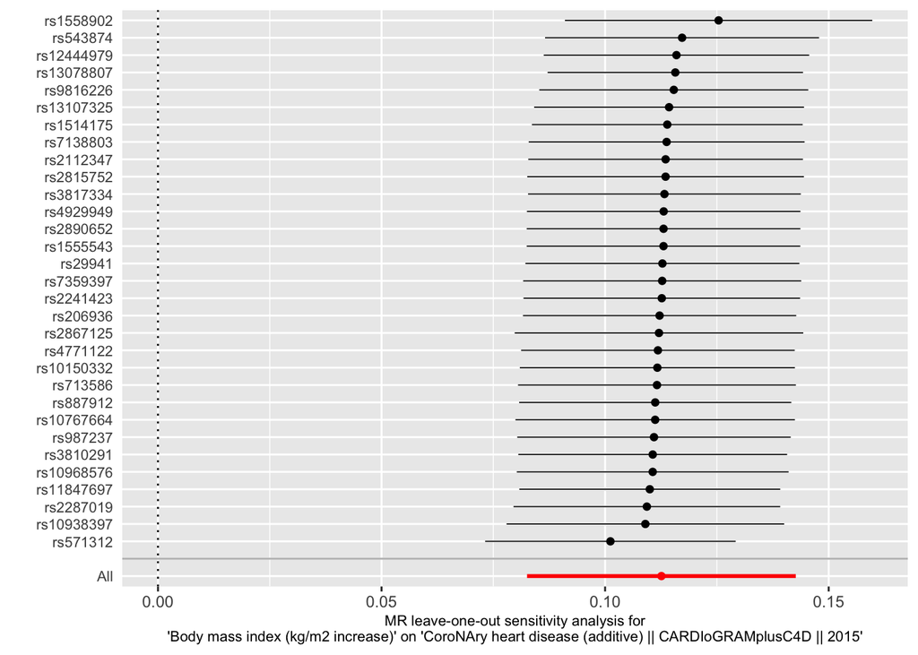

```r
res_loo <- mr_leaveoneout(dat)
p3 <- mr_leaveoneout_plot(res_loo)
p3[[1]]
```

Specify the test to use e.g. `mr_leaveoneout(dat, method = mr_egger_regression)` to use Egger regression.

### Funnel plot

Asymmetry in a funnel plot is useful for gauging the reliability of a particular MR analysis. Funnel plots can be produced using the single SNP results as follows:

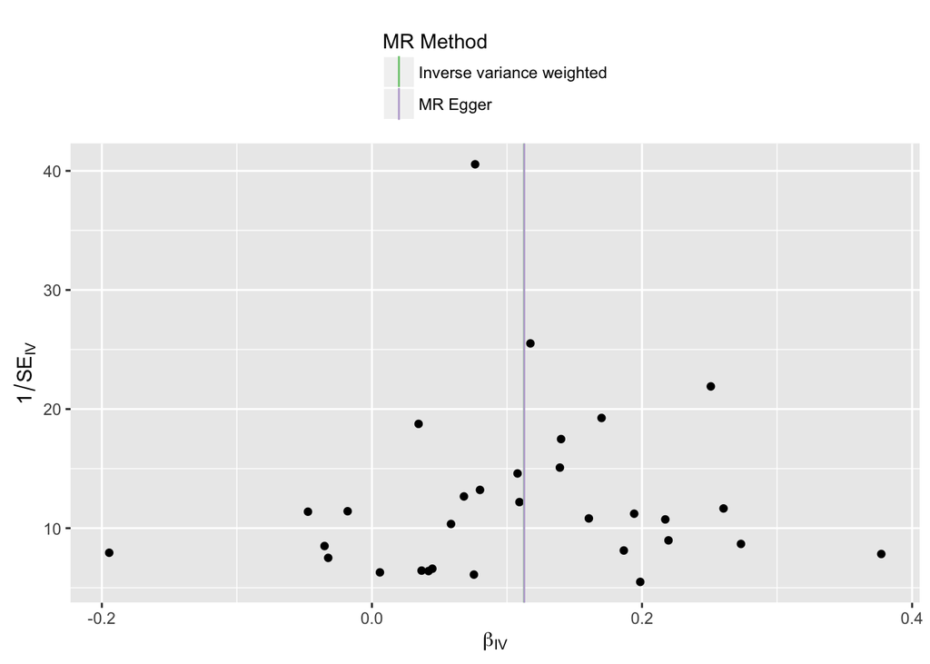

```r
res_single <- mr_singlesnp(dat)
p4 <- mr_funnel_plot(res_single)
p4[[1]]
```

## Reports

A report can be generated that performs all MR analyses, sensitivity analyses, and plots, and presents them in a single self-contained html web page, word document, or pdf document.

```r
mr_report(dat)
```

By default this produces a html file in the current working directory, but see the help pages on how to modify this.

This function will create a separate report file for every exposure-outcome combination that is present in the `dat` object.

# References

Bowden, Jack, George Davey Smith, and Stephen Burgess. 2015. “Mendelian randomization with invalid instruments: effect estimation and bias detection through Egger regression.” *International Journal of Epidemiology* In press.

Davey Smith, G., and S. Ebrahim. 2003. “’Mendelian randomization’: can genetic epidemiology contribute to understanding environmental determinants of disease?” *International Journal of Epidemiology* 32 (1): 1–22. doi:10.1093/ije/dyg070.

Davey Smith, George, and Gibran Hemani. 2014. “Mendelian randomization: genetic anchors for causal inference in epidemiological studies.” *Human Molecular Genetics* 23 (R1). Oxford Univ Press: R89—–98. doi:10.1093/hmg/ddu328.

Pierce, Brandon L, and Stephen Burgess. 2013. “Efficient design for Mendelian randomization studies: subsample and 2-sample instrumental variable estimators.” *American Journal of Epidemiology* 178 (7): 1177–84. doi:10.1093/aje/kwt084.